# Agenda Bias 1

Control for topical content & topical prevalence

To allow for an operationalization of agenda bias, I use parties’ campaign communication as an approximation of the potential universe of news stories (D’Alessio & Allen, 2000; Eberl, 2017). I compare the policy issues addressed in campaign communication (i.e., the party agenda) with the policy issues the parties address in media coverage (i.e., the mediated party agenda).

To discover the latent topics in the corpus of press releases (1.942) and news articles (11.880), a structural topic modeling (STM) developed by [Roberts (2016)](https://scholar.princeton.edu/sites/default/files/bstewart/files/a_model_of_text_for_experimentation_in_the_social_sciences.pdf) is applied. The STM is an unsupervised machine learning approach that models topics as multinomial distributions of words and documents as multinomial distributions of topics, allowing to incorporate external variables that effect both, topical content and topical prevalence.

# Structural Topic Model

## Build Corpus

I included the document source as a control for the topical topical prevalence and the type (press release or news article) as a control for topical content. Thus, I assume that the distribution of topics depends on the source and the word distribution within each topic differes between party press releases and news articles. The number of topics is set to 40.

## Select Model

STM assumes a fixed user-specified number of topics. There is not a “right” answer to the number of topics that are appropriate for a given corpus (Grimmer and Stewart 2013), but the function searchK uses a data-driven approach to selecting the number of topics. The function will perform several automated tests to help choose the number of topics including calculating the held out likelihood (Wallach et al. 2009) and performing a residual analysis (Taddy 2012).

## Results

### Label topics

To explore the words associated with each topic we use the words with the highest probability in each topic. As we included the source type (press release or news paper) as a control for the topical content (the word distribution of each topic), we have two different labels for each topic.

|  | topic | topic_name_news | topic_name_press |
| --- | --- | --- | --- |
| 1 | 1 | Topic 1 : eu europa deutschland europäischen | Topic 1 : eu europäischen europa europäisch |
| 2 | 2 | Topic 2 : schulz spd martin gabriel | Topic 2 : schulz martin sicherheit nato |
| 3 | 3 | Topic 3 : spd koalit union neuwahlen | Topic 3 : koalit grünen schwarz jamaika |
| 4 | 4 | Topic 4 : grünen habeck schleswig holstein | Topic 4 : gewählt europarat grupp vorsitzenden |
| 5 | 5 | Topic 5 : vw diesel auto konzern | Topic 5 : bundesregierung dagdelen deutschland erklärt |
| 6 | 6 | Topic 6 : bundeswehr leyen soldaten ursula | Topic 6 : bundeswehr soldaten leyen deutschen |
| 7 | 7 | Topic 7 : the of ge be | Topic 7 : olympischen athleten school athletinnen |
| 8 | 8 | Topic 8 : trump usa präsident russland | Topic 8 : bundesregierung usa russland trump |
| 9 | 9 | Topic 9 : welt menschen land deutschland | Topic 9 : engag bedeutung zukunft gesellschaft |
| 10 | 10 | Topic 10 : grünen özdemir göring eckardt | Topic 10 : landwirtschaft verbrauch verbraucherinnen verbraucherschutz |
| 11 | 11 | Topic 11 : afd petri partei fraktion | Topic 11 : sachsen anhalt meuthen poggenburg |
| 12 | 12 | Topic 12 : prozent spd cdu fdp | Topic 12 : prozent stimmen arbeitsgrupp entwicklung |
| 13 | 13 | Topic 13 : link linken wagenknecht rot | Topic 13 : fraktion kommentiert vorsitzend ernst |
| 14 | 14 | Topic 14 : spd union groko koalitionsverhandlungen | Topic 14 : bundestagsfrakt kommunen wichtig sprecher |
| 15 | 15 | Topic 15 : cdu niedersachsen spd august | Topic 15 : christen deutschland bericht heiner |
| 16 | 16 | Topic 16 : maizièr innenminist verfassungsschutz behörden | Topic 16 : urteil bundesregierung bundesverfassungsgericht daten |
| 17 | 17 | Topic 17 : euro union milliarden spd | Topic 17 : euro milliarden jahr bund |
| 18 | 18 | Topic 18 : kohl helmut cdu jahr | Topic 18 : kultur deutschen bundestagsfrakt ost |
| 19 | 19 | Topic 19 : auftritt rede bühne abend | Topic 19 : christin buchholz menschen besuch |
| 20 | 20 | Topic 20 : frauen staatsanwaltschaft ermittlungen jahr | Topic 20 : frauen gewalt hilf menschenrecht |
| 21 | 21 | Topic 21 : fdp jamaika grünen lindner | Topic 21 : demokraten deutschland lindner freien |
| 22 | 22 | Topic 22 : csu seehof horst söder | Topic 22 : bayern forderungen forderung obergrenz |
| 23 | 23 | Topic 23 : afd partei parteien facebook | Topic 23 : partei facebook deutschland politisch |
| 24 | 24 | Topic 24 : schulz duell merkel tv | Topic 24 : wähler bundesvorstandsmitgli illegalen volk |
| 25 | 25 | Topic 25 : jahr deutschland menschen stiftung | Topic 25 : deutschland bildung bund menschen |
| 26 | 26 | Topic 26 : muslim islam deutschland stadt | Topic 26 : öffentlich rundfunk rechtlichen medien |
| 27 | 27 | Topic 27 : spahn berlin antisemitismu israel | Topic 27 : bürgerversicherung jen spahn medizin |
| 28 | 28 | Topic 28 : merkel cdu angela kanzlerin | Topic 28 : merkel angela bundeskanzlerin afrika |
| 29 | 29 | Topic 29 : türkei erdogan deutschland türkischen | Topic 29 : türkei erdogan türkischen bundesregierung |
| 30 | 30 | Topic 30 : afd höcke partei björn | Topic 30 : bundesvorstand anhalt andré partei |
| 31 | 31 | Topic 31 : maa gesetz heiko justizminist | Topic 31 : de masi gesetzentwurf gesetz |
| 32 | 32 | Topic 32 : flüchtling familiennachzug deutschland flüchtlingen | Topic 32 : menschen afghanistan familiennachzug jelpk |
| 33 | 33 | Topic 33 : afd weidel gauland alic | Topic 33 : deutschland weidel alic deutschen |
| 34 | 34 | Topic 34 : berlin polizei tegel müller | Topic 34 : berlin air beschäftigten bundesregierung |
| 35 | 35 | Topic 35 : kinder eltern schulen frauen | Topic 35 : kinder arbeit menschen pflege |
| 36 | 36 | Topic 36 : bundestag afd abgeordneten abgeordnet | Topic 36 : bundestag antrag deutschen religionsfreiheit |
| 37 | 37 | Topic 37 : spd partei koalit große | Topic 37 : gabriel macron deutsch französischen |
| 38 | 38 | Topic 38 : bosbach maischberg ströbele duisburg | Topic 38 : angriff verein dialog ertragen |
| 39 | 39 | Topic 39 : hamburg gipfel polizei scholz | Topic 39 : polizei hamburg deutschland rechtsstaat |
| 40 | 40 | Topic 40 : politik peter altmaier wirtschaft | Topic 40 : wirtschaft politik lobbi deutschland |

### Topic frequency

The expected proportion of the corpus that belongs to each topic is used to geht an initial overview of the results. The figure below displays the topics ordered by their expected frequency across the corpus. The four most frequent words in each topic are used as a label for that topic.

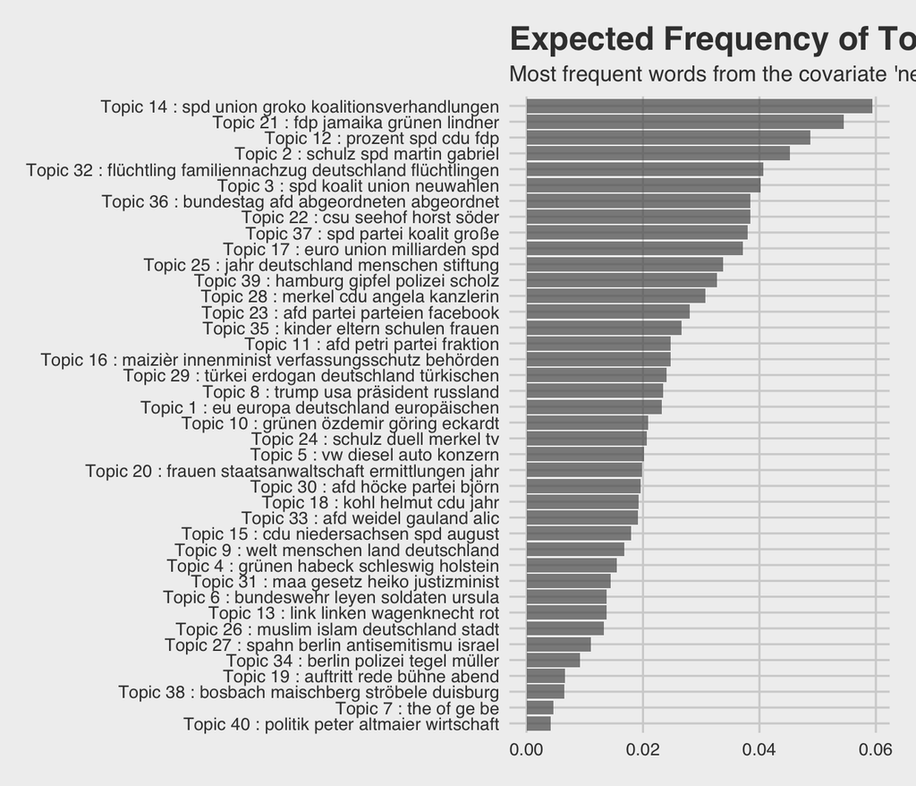

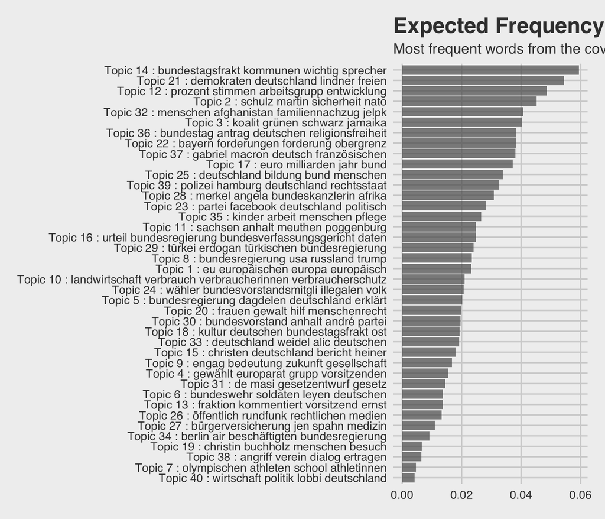

### Measure Agendas

For each document, we have a distribution over all topics:

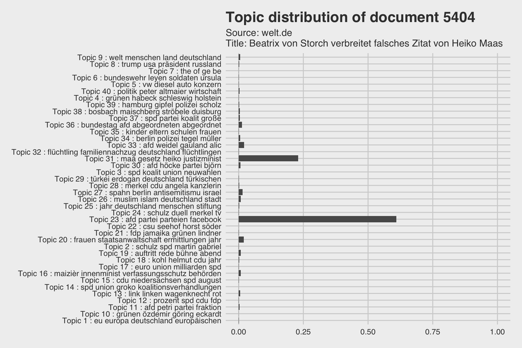

What is the document acutally about?

|  | source | title_text |
| --- | --- | --- |
| 1 | welt.de | Beatrix von Storch verbreitet falsches Zitat von Heiko Maas Die AfD-Politikerin Beatrix von Storch kommentiert auf Twitter ein vermeintliches Zitat von Justizminister Heiko Maas. Als sie darauf angesp… |

Agendas were measured in terms of percentage distributions across the 40 topics. For each source the average distribution of each topic is calculated.

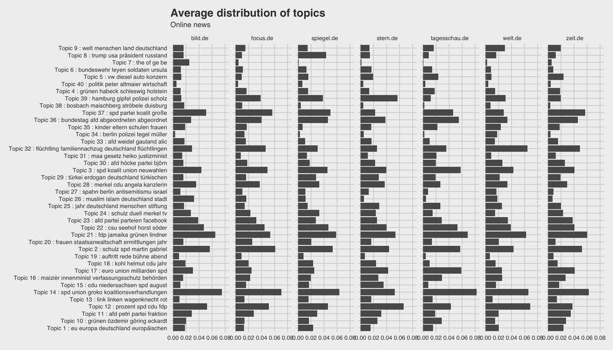

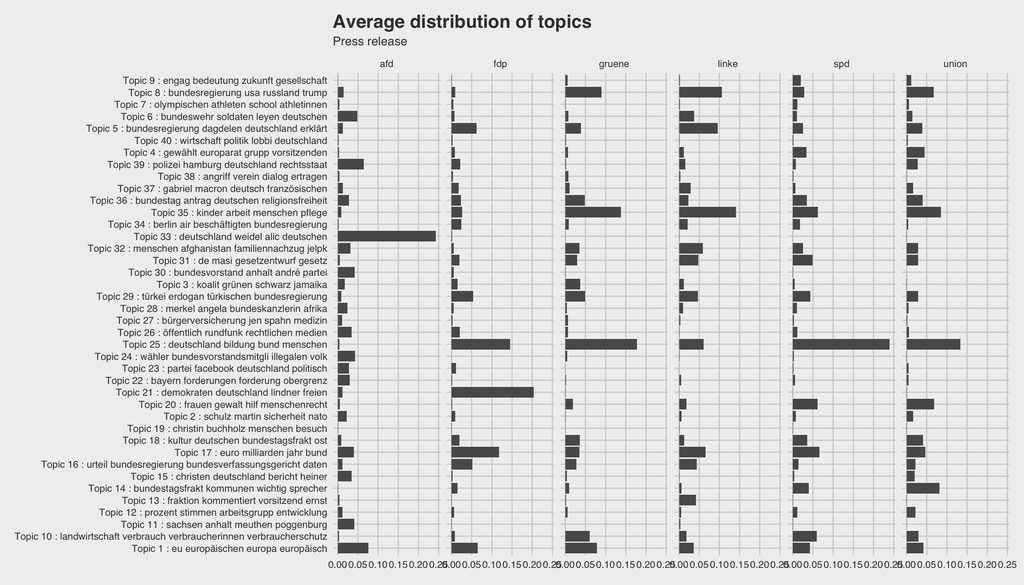

Then, we estimated bivariate correlations between party agendas and the mediated party agendas in the online news. These correlations represent the agenda selectivity each party experiences in each media outlet. The higher the correlation, the more congruent both agendas are (Brandenburg, 2005; Harris, Fury, & Lock, 2006; Kim, Xiang, & Kiousis, 2011).

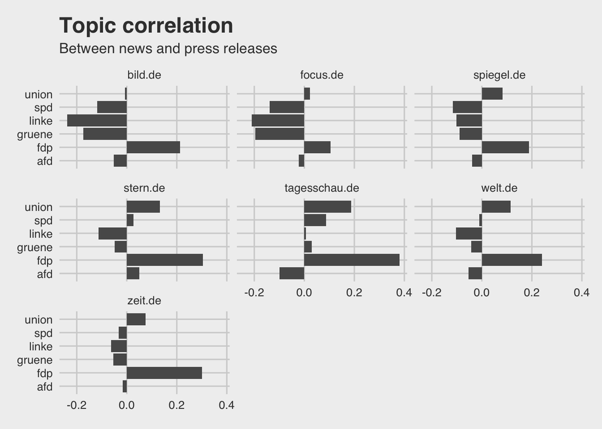

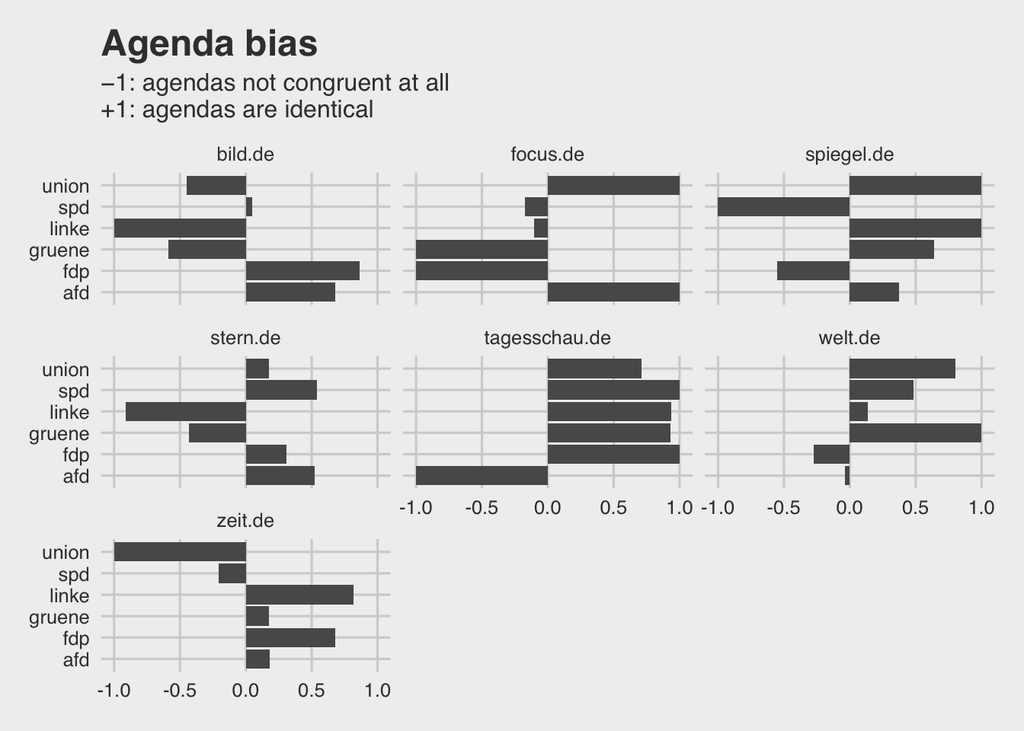